# Price Prediction for Airbnb rental apartments in Amsterdam

# Machine Learning

## Building Regression Models

We have built 3 linear regression models for predicting price. They all have price as the target variable while the predictor variables vary in length. The models are ordered by increasing complexity. Increasing complexity means that models will include different functional models and interactions. The regression models can be seen in the table below:

**Versions of the Airbnb Apartment Price Prediction Models**

| Model | Predictor Variables |
| --- | --- |
| M1 | = District, guests accommodated, log of number of beds, number of bedrooms, average review scores, missing score flag, guests accommodated (squared term), room type, minimum nights, number of reviews,… |
| M2 | = M1 + all amenities |
| M3 | = M2 + amenities interactions |

After cleaning and filtering our data, we were left with 13521 observations. From this, we will 30% of the data at random and use it as a holdout set. The rest of the workout set will be used for cross validation with 5 folds of training and test sets.

## OLS Linear Regression

First we trained and tested all the regression models using all the observations in the work set (train + test sets) and calculated the R-squared and BIC. Then we again ran the regression models via 5 fold cross validation to calculate the train RMSE and test RMSE on the five training and test sets. RMSE stands for Root Mean Squared Error (MSE) and is the square root of the average Mean Square Error which is the sum of squared residuals. The R-squared improves as we add more predictor variables into the models. Model 3 which contains all the individual variables as well as interaction variables gives an R-square of 0.38 which means the that this model explains 38% of the variation in prices. Meanwhile, Model 2 provided the lowest BIC of the 3 models (lower values of BIC indicate better performance).

**Comparing Model Fit measures**

| Model | N predictors | R-squared | BIC | Training RMSE | Test RMSE |
| --- | --- | --- | --- | --- | --- |
| Model 1 | 17 | 0.33 | 105066 | 61.80 | 61.65 |
| Model 2 | 84 | 0.38 | 105011 | 60.23 | 59.51 |
| Model 3 | 103 | 0.38 | 105151 | 60.25 | 59.41 |

We also plot the actual price vs predicted plot to see how accurately our model predicted. A lot of our predicted values in the holdout set center around the 45 degree line. If our predicted values were equal to actual values, our points would all lie on the 45 degree line. Hence, our model is over estimating and under estimating at times and needs to be improved.

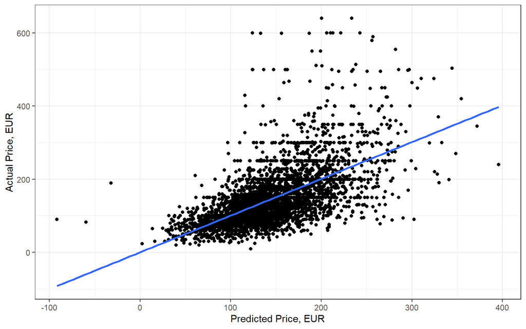

## Random Forest

Random Forest is an ensemble method based on regression trees. It involves building many imperfect trees and averaging the predictions of all the trees to arrive at an average value. This leads to a much better prediction than a single model.

We will be testing two models through Random Forest:

**Versions of the Airbnb Apartment Price Prediction Models for Random Forest**

| Model | Predictor Variables |
| --- | --- |
| M1 | = District, guests accommodated, log of number of beds, number of bedrooms, average review scores, missing score flag, guests accommodated (squared term), room type, minimum nights, number of reviews,… |
| M2 | = M1 + all amenities |

Random Forest models require setting up tuning parameters which can help achieve us a low RSME and hence produce better predictions. Our data split remains the same. We use 30% of the cleaned data as a holdout set and use the rest 70% for 5 fold cross validation. The Random Forest models require some tuning and we will provide several values to the tuning parameter so that cross validation can find us the tuning parameter values with the lowest test set RMSE.

The first tuning parameter is the number of bootstrap samples to be drawn. We take the default value of 500. Second parameter is the number of variables (mtry) to be considered at each node in each tree. General rule of thumb is to take square root of the number of variables hence we used range of 4-8 for model 1 and range of 7 - 11 for model 2. Third parameter is the minimum number of observations (min.nodes) in terminal nodes which we have taken as (2,4,6,8) for model 1 and (5,10,15) for model 2.

**Random Forest RMSE by tuning parameters (Model 1)**

| nodes | 4 | 6 | 8 |
| --- | --- | --- | --- |
| 2 | 64.36319 | 65.68762 | 66.45970 |
| 4 | 64.27608 | 65.38384 | 66.13335 |
| 6 | 64.13450 | 65.13131 | 65.77424 |
| 8 | 64.09034 | 65.00619 | 65.53509 |

**Random Forest RMSE by tuning parameters (Model 2)**

| nodes | 7 | 9 | 11 |
| --- | --- | --- | --- |
| 5 | 61.16677 | 61.13912 | 61.20022 |
| 10 | 61.20003 | 61.13666 | 61.13311 |
| 15 | 61.22560 | 61.13615 | 61.13603 |

**RMSE fold results for all models**

|  | Model 1 | Model 2 |
| --- | --- | --- |
| Fold 1 | 65.8580 | 62.7410 |
| Fold 2 | 64.3810 | 61.8180 |
| Fold 3 | 64.7570 | 61.6630 |
| Fold 4 | 62.4130 | 59.3230 |
| Fold 5 | 63.0430 | 60.1210 |
| Average | 64.0904 | 61.1332 |

### Variable Importance

In random forests, there can be a lot of trees that are grown in a correlated fashion and each can grow very large. So unlike linear regression coefficients, its not possible to understand the relationship between target and explanatory variables. In its place, we can use a diagnostic tool like Variable Importance charts. We run model 2 on the holdout set and produce the following two Variable Importance charts:

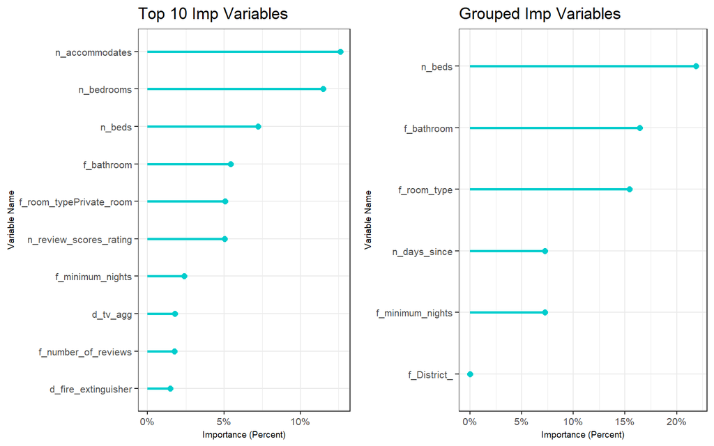